# Section 5: dplyr Fundamentals

```r
library(tidyverse)
# Uncomment the line below to install the package (only need to do this once)
#install.packages("magrittr")

library(magrittr)
```

## The pipe

The pipe passes the object on the left to the function on the right. (Ctrl + Shift + M) or (Command + Shift + M)

```r
subtract(5, 2) # 5 - 2 = 3
```

```
## [1] 3
```

```r
5 %>% subtract(2) # This is 5 - 2 = 3, not 2 - 5 = -3
```

```
## [1] 3
```

It makes things much more readable when we have multiple nested functions.

```r
divide_by(raise_to_power(multiply_by(subtract(5, 2), 4), 2), 12)
```

```
## [1] 12
```

```r
5 %>%
  subtract(2) %>%
  multiply_by(4) %>%
  raise_to_power(2) %>%
  divide_by(12)
```

```
## [1] 12
```

Try recreating the following code with the pipe:

```r
sqrt(add(divide_by(30, 10), 6))

30 %>%
  divide_by(10) %>%
  add(6) %>%
  # and so on
```

```
## Error in parse(text = input): <text>:7:0: unexpected end of input
## 5:   add(6) %>%
## 6:   # and so on
##   ^
```

## dplyr basics

We’ll continue working with the Palmer penguins data as an example.

```r
penguins <- read_csv("../../data/penguins.csv")
```

### Column editors

`select()` reduces the df to the columns we specify.

```r
# select just species, sex, flipper length, and body mass
penguins %>%
  select(species, sex, flipper_length_mm, body_mass_g)
```

```
## # A tibble: 333 × 4
##    species sex    flipper_length_mm body_mass_g
##    <chr>   <chr>              <dbl>       <dbl>
##  1 Adelie  male                 181        3750
##  2 Adelie  female               186        3800
##  3 Adelie  female               195        3250
##  4 Adelie  female               193        3450
##  5 Adelie  male                 190        3650
##  6 Adelie  female               181        3625
##  7 Adelie  male                 195        4675
##  8 Adelie  female               182        3200
##  9 Adelie  male                 191        3800
## 10 Adelie  male                 198        4400
## # ℹ 323 more rows
```

```r
# Can also "de-select"
# e.g. select everything except island and
# columns body mass through year

penguins %>%
  select(-island, -(body_mass_g:year))
```

```
## # A tibble: 333 × 4
##    species bill_length_mm bill_depth_mm flipper_length_mm
##    <chr>            <dbl>         <dbl>             <dbl>
##  1 Adelie            39.1          18.7               181
##  2 Adelie            39.5          17.4               186
##  3 Adelie            40.3          18                 195
##  4 Adelie            36.7          19.3               193
##  5 Adelie            39.3          20.6               190
##  6 Adelie            38.9          17.8               181
##  7 Adelie            39.2          19.6               195
##  8 Adelie            41.1          17.6               182
##  9 Adelie            38.6          21.2               191
## 10 Adelie            34.6          21.1               198
## # ℹ 323 more rows
```

`relocate()` moves columns without adding or removing any. By default, it takes columns and moves them to the *left*.

```r
penguins %>%
  relocate(year, sex)
```

```
## # A tibble: 333 × 8
##     year sex    species island    bill_length_mm bill_depth_mm flipper_length_mm
##    <dbl> <chr>  <chr>   <chr>              <dbl>         <dbl>             <dbl>
##  1  2007 male   Adelie  Torgersen           39.1          18.7               181
##  2  2007 female Adelie  Torgersen           39.5          17.4               186
##  3  2007 female Adelie  Torgersen           40.3          18                 195
##  4  2007 female Adelie  Torgersen           36.7          19.3               193
##  5  2007 male   Adelie  Torgersen           39.3          20.6               190
##  6  2007 female Adelie  Torgersen           38.9          17.8               181
##  7  2007 male   Adelie  Torgersen           39.2          19.6               195
##  8  2007 female Adelie  Torgersen           41.1          17.6               182
##  9  2007 male   Adelie  Torgersen           38.6          21.2               191
## 10  2007 male   Adelie  Torgersen           34.6          21.1               198
## # ℹ 323 more rows
## # ℹ 1 more variable: body_mass_g <dbl>
```

Or, we can move columns to specific places.

```r
penguins %>%
  relocate(island, .after = year)
```

```
## # A tibble: 333 × 8
##    species bill_length_mm bill_depth_mm flipper_length_mm body_mass_g sex
##    <chr>            <dbl>         <dbl>             <dbl>       <dbl> <chr>
##  1 Adelie            39.1          18.7               181        3750 male
##  2 Adelie            39.5          17.4               186        3800 female
##  3 Adelie            40.3          18                 195        3250 female
##  4 Adelie            36.7          19.3               193        3450 female
##  5 Adelie            39.3          20.6               190        3650 male
##  6 Adelie            38.9          17.8               181        3625 female
##  7 Adelie            39.2          19.6               195        4675 male
##  8 Adelie            41.1          17.6               182        3200 female
##  9 Adelie            38.6          21.2               191        3800 male
## 10 Adelie            34.6          21.1               198        4400 male
## # ℹ 323 more rows
## # ℹ 2 more variables: year <dbl>, island <chr>
```

`rename()` changes the column names. Write `new_name = old_name`.

```r
penguins %>%
  rename(species_name = species, island_name = island)
```

```
## # A tibble: 333 × 8
##    species_name island_name bill_length_mm bill_depth_mm flipper_length_mm
##    <chr>        <chr>                <dbl>         <dbl>             <dbl>
##  1 Adelie       Torgersen             39.1          18.7               181
##  2 Adelie       Torgersen             39.5          17.4               186
##  3 Adelie       Torgersen             40.3          18                 195
##  4 Adelie       Torgersen             36.7          19.3               193
##  5 Adelie       Torgersen             39.3          20.6               190
##  6 Adelie       Torgersen             38.9          17.8               181
##  7 Adelie       Torgersen             39.2          19.6               195
##  8 Adelie       Torgersen             41.1          17.6               182
##  9 Adelie       Torgersen             38.6          21.2               191
## 10 Adelie       Torgersen             34.6          21.1               198
## # ℹ 323 more rows
## # ℹ 3 more variables: body_mass_g <dbl>, sex <chr>, year <dbl>
```

Note that none of these actions are changing the `penguins` object. If we want to save the results, we can use `<-`, either to define a new object or overwrite the current object.

```r
# Let's make a smaller penguin dataset that's easier to see
penguins_small <- penguins %>%
    select(species, sex, bill_length_mm, bill_depth_mm)

penguins_small
```

```
## # A tibble: 333 × 4
##    species sex    bill_length_mm bill_depth_mm
##    <chr>   <chr>           <dbl>         <dbl>
##  1 Adelie  male             39.1          18.7
##  2 Adelie  female           39.5          17.4
##  3 Adelie  female           40.3          18
##  4 Adelie  female           36.7          19.3
##  5 Adelie  male             39.3          20.6
##  6 Adelie  female           38.9          17.8
##  7 Adelie  male             39.2          19.6
##  8 Adelie  female           41.1          17.6
##  9 Adelie  male             38.6          21.2
## 10 Adelie  male             34.6          21.1
## # ℹ 323 more rows
```

`mutate()` creates a new column. For example, make a new column whose value is constant for all rows.

```r
penguins_small %>%
  mutate(study = "Palmer")
```

```
## # A tibble: 333 × 5
##    species sex    bill_length_mm bill_depth_mm study
##    <chr>   <chr>           <dbl>         <dbl> <chr>
##  1 Adelie  male             39.1          18.7 Palmer
##  2 Adelie  female           39.5          17.4 Palmer
##  3 Adelie  female           40.3          18   Palmer
##  4 Adelie  female           36.7          19.3 Palmer
##  5 Adelie  male             39.3          20.6 Palmer
##  6 Adelie  female           38.9          17.8 Palmer
##  7 Adelie  male             39.2          19.6 Palmer
##  8 Adelie  female           41.1          17.6 Palmer
##  9 Adelie  male             38.6          21.2 Palmer
## 10 Adelie  male             34.6          21.1 Palmer
## # ℹ 323 more rows
```

Or, we can change the value of an existing column.

```r
penguins_small %>%
  mutate(sex = substr(toupper(sex), 1, 1))
```

```
## # A tibble: 333 × 4
##    species sex   bill_length_mm bill_depth_mm
##    <chr>   <chr>          <dbl>         <dbl>
##  1 Adelie  M               39.1          18.7
##  2 Adelie  F               39.5          17.4
##  3 Adelie  F               40.3          18
##  4 Adelie  F               36.7          19.3
##  5 Adelie  M               39.3          20.6
##  6 Adelie  F               38.9          17.8
##  7 Adelie  M               39.2          19.6
##  8 Adelie  F               41.1          17.6
##  9 Adelie  M               38.6          21.2
## 10 Adelie  M               34.6          21.1
## # ℹ 323 more rows
```

More commonly, create a new column based on the values of other columns. Let’s estimate the volume of a penguin bill as a cylinder.

```r
penguins_small %>%
  mutate(bill_cross_section_mm2 = pi * (bill_depth_mm / 2)^2,

         bill_vol_mm3 = bill_cross_section_mm2 * bill_length_mm
)
```

```
## # A tibble: 333 × 6
##    species sex    bill_length_mm bill_depth_mm bill_cross_section_mm2
##    <chr>   <chr>           <dbl>         <dbl>                  <dbl>
##  1 Adelie  male             39.1          18.7                   275.
##  2 Adelie  female           39.5          17.4                   238.
##  3 Adelie  female           40.3          18                     254.
##  4 Adelie  female           36.7          19.3                   293.
##  5 Adelie  male             39.3          20.6                   333.
##  6 Adelie  female           38.9          17.8                   249.
##  7 Adelie  male             39.2          19.6                   302.
##  8 Adelie  female           41.1          17.6                   243.
##  9 Adelie  male             38.6          21.2                   353.
## 10 Adelie  male             34.6          21.1                   350.
## # ℹ 323 more rows
## # ℹ 1 more variable: bill_vol_mm3 <dbl>
```

### Row editors

`arrange()` lets us order the rows while keeping the columns unchanged. It sorts rows from smallest to largest.

```r
penguins %>%
  arrange(flipper_length_mm)
```

```
## # A tibble: 333 × 8
##    species   island   bill_length_mm bill_depth_mm flipper_length_mm body_mass_g
##    <chr>     <chr>             <dbl>         <dbl>             <dbl>       <dbl>
##  1 Adelie    Biscoe             37.9          18.6               172        3150
##  2 Adelie    Biscoe             37.8          18.3               174        3400
##  3 Adelie    Torgers…           40.2          17                 176        3450
##  4 Adelie    Dream              39.5          16.7               178        3250
##  5 Adelie    Dream              37.2          18.1               178        3900
##  6 Adelie    Dream              33.1          16.1               178        2900
##  7 Chinstrap Dream              46.1          18.2               178        3250
##  8 Adelie    Biscoe             37.7          18.7               180        3600
##  9 Adelie    Biscoe             38.8          17.2               180        3800
## 10 Adelie    Biscoe             40.5          18.9               180        3950
## # ℹ 323 more rows
## # ℹ 2 more variables: sex <chr>, year <dbl>
```

```r
penguins %>%
  arrange(island)
```

```
## # A tibble: 333 × 8
##    species island bill_length_mm bill_depth_mm flipper_length_mm body_mass_g
##    <chr>   <chr>           <dbl>         <dbl>             <dbl>       <dbl>
##  1 Adelie  Biscoe           37.8          18.3               174        3400
##  2 Adelie  Biscoe           37.7          18.7               180        3600
##  3 Adelie  Biscoe           35.9          19.2               189        3800
##  4 Adelie  Biscoe           38.2          18.1               185        3950
##  5 Adelie  Biscoe           38.8          17.2               180        3800
##  6 Adelie  Biscoe           35.3          18.9               187        3800
##  7 Adelie  Biscoe           40.6          18.6               183        3550
##  8 Adelie  Biscoe           40.5          17.9               187        3200
##  9 Adelie  Biscoe           37.9          18.6               172        3150
## 10 Adelie  Biscoe           40.5          18.9               180        3950
## # ℹ 323 more rows
## # ℹ 2 more variables: sex <chr>, year <dbl>
```

If we want to go from largest to smallest, use `desc`.

```r
penguins %>%
  arrange(desc(island))
```

```
## # A tibble: 333 × 8
##    species island    bill_length_mm bill_depth_mm flipper_length_mm body_mass_g
##    <chr>   <chr>              <dbl>         <dbl>             <dbl>       <dbl>
##  1 Adelie  Torgersen           39.1          18.7               181        3750
##  2 Adelie  Torgersen           39.5          17.4               186        3800
##  3 Adelie  Torgersen           40.3          18                 195        3250
##  4 Adelie  Torgersen           36.7          19.3               193        3450
##  5 Adelie  Torgersen           39.3          20.6               190        3650
##  6 Adelie  Torgersen           38.9          17.8               181        3625
##  7 Adelie  Torgersen           39.2          19.6               195        4675
##  8 Adelie  Torgersen           41.1          17.6               182        3200
##  9 Adelie  Torgersen           38.6          21.2               191        3800
## 10 Adelie  Torgersen           34.6          21.1               198        4400
## # ℹ 323 more rows
## # ℹ 2 more variables: sex <chr>, year <dbl>
```

```r
# Advanced note that you don't have to know: R considers
# uppercase as "greater" than lowercase IF IT IS THE SAME LETTER.
# Otherwise, it ignores case.
# So, "B" > "b", but "A" < "b".
```

You can also provide further variables to break ties in the first one, if desired. If not, the order in the original dataframe will break the tie.

The `filter()` command chooses specific rows based on a condition. In R, conditions evaluate to `TRUE` or `FALSE`.

```r
penguins
```

```
## # A tibble: 333 × 8
##    species island    bill_length_mm bill_depth_mm flipper_length_mm body_mass_g
##    <chr>   <chr>              <dbl>         <dbl>             <dbl>       <dbl>
##  1 Adelie  Torgersen           39.1          18.7               181        3750
##  2 Adelie  Torgersen           39.5          17.4               186        3800
##  3 Adelie  Torgersen           40.3          18                 195        3250
##  4 Adelie  Torgersen           36.7          19.3               193        3450
##  5 Adelie  Torgersen           39.3          20.6               190        3650
##  6 Adelie  Torgersen           38.9          17.8               181        3625
##  7 Adelie  Torgersen           39.2          19.6               195        4675
##  8 Adelie  Torgersen           41.1          17.6               182        3200
##  9 Adelie  Torgersen           38.6          21.2               191        3800
## 10 Adelie  Torgersen           34.6          21.1               198        4400
## # ℹ 323 more rows
## # ℹ 2 more variables: sex <chr>, year <dbl>
```

```r
penguins$species
```

```
##   [1] "Adelie"    "Adelie"    "Adelie"    "Adelie"    "Adelie"    "Adelie"
##   [7] "Adelie"    "Adelie"    "Adelie"    "Adelie"    "Adelie"    "Adelie"
##  [13] "Adelie"    "Adelie"    "Adelie"    "Adelie"    "Adelie"    "Adelie"
##  [19] "Adelie"    "Adelie"    "Adelie"    "Adelie"    "Adelie"    "Adelie"
##  [25] "Adelie"    "Adelie"    "Adelie"    "Adelie"    "Adelie"    "Adelie"
##  [31] "Adelie"    "Adelie"    "Adelie"    "Adelie"    "Adelie"    "Adelie"
##  [37] "Adelie"    "Adelie"    "Adelie"    "Adelie"    "Adelie"    "Adelie"
##  [43] "Adelie"    "Adelie"    "Adelie"    "Adelie"    "Adelie"    "Adelie"
##  [49] "Adelie"    "Adelie"    "Adelie"    "Adelie"    "Adelie"    "Adelie"
##  [55] "Adelie"    "Adelie"    "Adelie"    "Adelie"    "Adelie"    "Adelie"
##  [61] "Adelie"    "Adelie"    "Adelie"    "Adelie"    "Adelie"    "Adelie"
##  [67] "Adelie"    "Adelie"    "Adelie"    "Adelie"    "Adelie"    "Adelie"
##  [73] "Adelie"    "Adelie"    "Adelie"    "Adelie"    "Adelie"    "Adelie"
##  [79] "Adelie"    "Adelie"    "Adelie"    "Adelie"    "Adelie"    "Adelie"
##  [85] "Adelie"    "Adelie"    "Adelie"    "Adelie"    "Adelie"    "Adelie"
```

[output cut: 41 more lines]

```r
# For each row in the data, check whether its species is Chinstrap
penguins$species == "Chinstrap"
```

```
##   [1] FALSE FALSE FALSE FALSE FALSE FALSE FALSE FALSE FALSE FALSE FALSE FALSE
##  [13] FALSE FALSE FALSE FALSE FALSE FALSE FALSE FALSE FALSE FALSE FALSE FALSE
##  [25] FALSE FALSE FALSE FALSE FALSE FALSE FALSE FALSE FALSE FALSE FALSE FALSE
##  [37] FALSE FALSE FALSE FALSE FALSE FALSE FALSE FALSE FALSE FALSE FALSE FALSE
##  [49] FALSE FALSE FALSE FALSE FALSE FALSE FALSE FALSE FALSE FALSE FALSE FALSE
##  [61] FALSE FALSE FALSE FALSE FALSE FALSE FALSE FALSE FALSE FALSE FALSE FALSE
##  [73] FALSE FALSE FALSE FALSE FALSE FALSE FALSE FALSE FALSE FALSE FALSE FALSE
##  [85] FALSE FALSE FALSE FALSE FALSE FALSE FALSE FALSE FALSE FALSE FALSE FALSE
##  [97] FALSE FALSE FALSE FALSE FALSE FALSE FALSE FALSE FALSE FALSE FALSE FALSE
## [109] FALSE FALSE FALSE FALSE FALSE FALSE FALSE FALSE FALSE FALSE FALSE FALSE
## [121] FALSE FALSE FALSE FALSE FALSE FALSE FALSE FALSE FALSE FALSE FALSE FALSE
## [133] FALSE FALSE FALSE FALSE FALSE FALSE FALSE FALSE FALSE FALSE FALSE FALSE
## [145] FALSE FALSE FALSE FALSE FALSE FALSE FALSE FALSE FALSE FALSE FALSE FALSE
## [157] FALSE FALSE FALSE FALSE FALSE FALSE FALSE FALSE FALSE FALSE FALSE FALSE
## [169] FALSE FALSE FALSE FALSE FALSE FALSE FALSE FALSE FALSE FALSE FALSE FALSE
## [181] FALSE FALSE FALSE FALSE FALSE FALSE FALSE FALSE FALSE FALSE FALSE FALSE
## [193] FALSE FALSE FALSE FALSE FALSE FALSE FALSE FALSE FALSE FALSE FALSE FALSE
## [205] FALSE FALSE FALSE FALSE FALSE FALSE FALSE FALSE FALSE FALSE FALSE FALSE
## [217] FALSE FALSE FALSE FALSE FALSE FALSE FALSE FALSE FALSE FALSE FALSE FALSE
## [229] FALSE FALSE FALSE FALSE FALSE FALSE FALSE FALSE FALSE FALSE FALSE FALSE
## [241] FALSE FALSE FALSE FALSE FALSE FALSE FALSE FALSE FALSE FALSE FALSE FALSE
## [253] FALSE FALSE FALSE FALSE FALSE FALSE FALSE FALSE FALSE FALSE FALSE FALSE
## [265] FALSE  TRUE  TRUE  TRUE  TRUE  TRUE  TRUE  TRUE  TRUE  TRUE  TRUE  TRUE
## [277]  TRUE  TRUE  TRUE  TRUE  TRUE  TRUE  TRUE  TRUE  TRUE  TRUE  TRUE  TRUE
## [289]  TRUE  TRUE  TRUE  TRUE  TRUE  TRUE  TRUE  TRUE  TRUE  TRUE  TRUE  TRUE
## [301]  TRUE  TRUE  TRUE  TRUE  TRUE  TRUE  TRUE  TRUE  TRUE  TRUE  TRUE  TRUE
## [313]  TRUE  TRUE  TRUE  TRUE  TRUE  TRUE  TRUE  TRUE  TRUE  TRUE  TRUE  TRUE
## [325]  TRUE  TRUE  TRUE  TRUE  TRUE  TRUE  TRUE  TRUE  TRUE
```

Let’s keep only the rows corresponding to Chinstrap penguins.

```r
penguins %>%
  filter(species == "Chinstrap")
```

```
## # A tibble: 68 × 8
##    species   island bill_length_mm bill_depth_mm flipper_length_mm body_mass_g
##    <chr>     <chr>           <dbl>         <dbl>             <dbl>       <dbl>
##  1 Chinstrap Dream            46.5          17.9               192        3500
##  2 Chinstrap Dream            50            19.5               196        3900
##  3 Chinstrap Dream            51.3          19.2               193        3650
##  4 Chinstrap Dream            45.4          18.7               188        3525
##  5 Chinstrap Dream            52.7          19.8               197        3725
##  6 Chinstrap Dream            45.2          17.8               198        3950
##  7 Chinstrap Dream            46.1          18.2               178        3250
##  8 Chinstrap Dream            51.3          18.2               197        3750
##  9 Chinstrap Dream            46            18.9               195        4150
## 10 Chinstrap Dream            51.3          19.9               198        3700
## # ℹ 58 more rows
## # ℹ 2 more variables: sex <chr>, year <dbl>
```

We can set more complicated conditions with `&` (AND) and `|` (OR).

```r
# Only look at rows where body mass is between 3000 and 4000
penguins %>%
  filter(body_mass_g >= 3000 & body_mass_g <= 4000)
```

```
## # A tibble: 158 × 8
##    species island    bill_length_mm bill_depth_mm flipper_length_mm body_mass_g
##    <chr>   <chr>              <dbl>         <dbl>             <dbl>       <dbl>
##  1 Adelie  Torgersen           39.1          18.7               181        3750
##  2 Adelie  Torgersen           39.5          17.4               186        3800
##  3 Adelie  Torgersen           40.3          18                 195        3250
##  4 Adelie  Torgersen           36.7          19.3               193        3450
##  5 Adelie  Torgersen           39.3          20.6               190        3650
##  6 Adelie  Torgersen           38.9          17.8               181        3625
##  7 Adelie  Torgersen           41.1          17.6               182        3200
##  8 Adelie  Torgersen           38.6          21.2               191        3800
##  9 Adelie  Torgersen           36.6          17.8               185        3700
## 10 Adelie  Torgersen           38.7          19                 195        3450
## # ℹ 148 more rows
## # ℹ 2 more variables: sex <chr>, year <dbl>
```

```r
# Look at rows where body mass is less than 3000 OR above 4000
penguins %>%
  filter(body_mass_g < 3000 | body_mass_g > 4000)
```

```
## # A tibble: 175 × 8
##    species island    bill_length_mm bill_depth_mm flipper_length_mm body_mass_g
##    <chr>   <chr>              <dbl>         <dbl>             <dbl>       <dbl>
##  1 Adelie  Torgersen           39.2          19.6               195        4675
##  2 Adelie  Torgersen           34.6          21.1               198        4400
##  3 Adelie  Torgersen           42.5          20.7               197        4500
##  4 Adelie  Torgersen           46            21.5               194        4200
##  5 Adelie  Dream               39.2          21.1               196        4150
##  6 Adelie  Dream               39.8          19.1               184        4650
##  7 Adelie  Dream               44.1          19.7               196        4400
##  8 Adelie  Dream               39.6          18.8               190        4600
##  9 Adelie  Dream               42.3          21.2               191        4150
## 10 Adelie  Biscoe              40.1          18.9               188        4300
## # ℹ 165 more rows
## # ℹ 2 more variables: sex <chr>, year <dbl>
```

`drop_na()` removes any rows with missing values. In the `starwars` dataset, we have `NA` for the hair color of droids.

```r
# C-3PO and R2-D2 and R5-D4's hair_color are NA.
starwars
```

```
## # A tibble: 87 × 14
##    name     height  mass hair_color skin_color eye_color birth_year sex   gender
##    <chr>     <int> <dbl> <chr>      <chr>      <chr>          <dbl> <chr> <chr>
##  1 Luke Sk…    172    77 blond      fair       blue            19   male  mascu…
##  2 C-3PO       167    75 <NA>       gold       yellow         112   none  mascu…
##  3 R2-D2        96    32 <NA>       white, bl… red             33   none  mascu…
##  4 Darth V…    202   136 none       white      yellow          41.9 male  mascu…
##  5 Leia Or…    150    49 brown      light      brown           19   fema… femin…
##  6 Owen La…    178   120 brown, gr… light      blue            52   male  mascu…
##  7 Beru Wh…    165    75 brown      light      blue            47   fema… femin…
##  8 R5-D4        97    32 <NA>       white, red red             NA   none  mascu…
##  9 Biggs D…    183    84 black      light      brown           24   male  mascu…
## 10 Obi-Wan…    182    77 auburn, w… fair       blue-gray       57   male  mascu…
## # ℹ 77 more rows
## # ℹ 5 more variables: homeworld <chr>, species <chr>, films <list>,
## #   vehicles <list>, starships <list>
```

```r
# Normally, there are 87 characters
nrow(starwars)
```

```
## [1] 87
```

Now let’s get rid of those rows.

```r
# Goodbye to those rows! Now we skip right from Luke to Darth Vader.
starwars %>%
  drop_na(hair_color)
```

```
## # A tibble: 82 × 14
##    name     height  mass hair_color skin_color eye_color birth_year sex   gender
##    <chr>     <int> <dbl> <chr>      <chr>      <chr>          <dbl> <chr> <chr>
##  1 Luke Sk…    172    77 blond      fair       blue            19   male  mascu…
##  2 Darth V…    202   136 none       white      yellow          41.9 male  mascu…
##  3 Leia Or…    150    49 brown      light      brown           19   fema… femin…
##  4 Owen La…    178   120 brown, gr… light      blue            52   male  mascu…
##  5 Beru Wh…    165    75 brown      light      blue            47   fema… femin…
##  6 Biggs D…    183    84 black      light      brown           24   male  mascu…
##  7 Obi-Wan…    182    77 auburn, w… fair       blue-gray       57   male  mascu…
##  8 Anakin …    188    84 blond      fair       blue            41.9 male  mascu…
##  9 Wilhuff…    180    NA auburn, g… fair       blue            64   male  mascu…
## 10 Chewbac…    228   112 brown      unknown    blue           200   male  mascu…
## # ℹ 72 more rows
## # ℹ 5 more variables: homeworld <chr>, species <chr>, films <list>,
## #   vehicles <list>, starships <list>
```

```r
# After removing rows with NA, 82 rows are left
starwars %>%
  drop_na(hair_color) %>%
  nrow()
```

```
## [1] 82
```

By default, `drop.na` looks for missing values in ALL columns.

```r
example <- tibble(
  col1 = c(NA, 2, 3, 4),
  col2 = c(1, NA, 3, 4),
  col3 = c(1, 2, NA, 4),
  col4 = c(1, 2, 3, 4)
)

example
```

```
## # A tibble: 4 × 4
##    col1  col2  col3  col4
##   <dbl> <dbl> <dbl> <dbl>
## 1    NA     1     1     1
## 2     2    NA     2     2
## 3     3     3    NA     3
## 4     4     4     4     4
```

```r
example %>% drop_na()
```

```
## # A tibble: 1 × 4
##    col1  col2  col3  col4
##   <dbl> <dbl> <dbl> <dbl>
## 1     4     4     4     4
```

If we only want to drop NA values from a single column, specify the column name or use `filter`.

```r
example %>% drop_na(col1)
```

```
## # A tibble: 3 × 4
##    col1  col2  col3  col4
##   <dbl> <dbl> <dbl> <dbl>
## 1     2    NA     2     2
## 2     3     3    NA     3
## 3     4     4     4     4
```

```r
example %>%
  filter(!is.na(col1))
```

```
## # A tibble: 3 × 4
##    col1  col2  col3  col4
##   <dbl> <dbl> <dbl> <dbl>
## 1     2    NA     2     2
## 2     3     3    NA     3
## 3     4     4     4     4
```

```r
starwars %>%
  filter(!is.na(hair_color))
```

```
## # A tibble: 82 × 14
##    name     height  mass hair_color skin_color eye_color birth_year sex   gender
##    <chr>     <int> <dbl> <chr>      <chr>      <chr>          <dbl> <chr> <chr>
##  1 Luke Sk…    172    77 blond      fair       blue            19   male  mascu…
##  2 Darth V…    202   136 none       white      yellow          41.9 male  mascu…
##  3 Leia Or…    150    49 brown      light      brown           19   fema… femin…
##  4 Owen La…    178   120 brown, gr… light      blue            52   male  mascu…
##  5 Beru Wh…    165    75 brown      light      blue            47   fema… femin…
##  6 Biggs D…    183    84 black      light      brown           24   male  mascu…
##  7 Obi-Wan…    182    77 auburn, w… fair       blue-gray       57   male  mascu…
##  8 Anakin …    188    84 blond      fair       blue            41.9 male  mascu…
##  9 Wilhuff…    180    NA auburn, g… fair       blue            64   male  mascu…
## 10 Chewbac…    228   112 brown      unknown    blue           200   male  mascu…
## # ℹ 72 more rows
## # ℹ 5 more variables: homeworld <chr>, species <chr>, films <list>,
## #   vehicles <list>, starships <list>
```

### Try it out

Pretend your boss is looking at your computer at the penguins dataframe with you and making the following requests. Write code to respond to your boss’s requests.

“Show me just the penguins measured in 2009.”

```r
penguins %>%
  filter(year == 2009)
```

```
## # A tibble: 117 × 8
##    species island bill_length_mm bill_depth_mm flipper_length_mm body_mass_g
##    <chr>   <chr>           <dbl>         <dbl>             <dbl>       <dbl>
##  1 Adelie  Biscoe           35            17.9               192        3725
##  2 Adelie  Biscoe           41            20                 203        4725
##  3 Adelie  Biscoe           37.7          16                 183        3075
##  4 Adelie  Biscoe           37.8          20                 190        4250
##  5 Adelie  Biscoe           37.9          18.6               193        2925
##  6 Adelie  Biscoe           39.7          18.9               184        3550
##  7 Adelie  Biscoe           38.6          17.2               199        3750
##  8 Adelie  Biscoe           38.2          20                 190        3900
##  9 Adelie  Biscoe           38.1          17                 181        3175
## 10 Adelie  Biscoe           43.2          19                 197        4775
## # ℹ 107 more rows
## # ℹ 2 more variables: sex <chr>, year <dbl>
```

“Can you put what island it’s from at the beginning?”

```r
penguins %>%
  relocate(island)
```

```
## # A tibble: 333 × 8
##    island    species bill_length_mm bill_depth_mm flipper_length_mm body_mass_g
##    <chr>     <chr>            <dbl>         <dbl>             <dbl>       <dbl>
##  1 Torgersen Adelie            39.1          18.7               181        3750
##  2 Torgersen Adelie            39.5          17.4               186        3800
##  3 Torgersen Adelie            40.3          18                 195        3250
##  4 Torgersen Adelie            36.7          19.3               193        3450
##  5 Torgersen Adelie            39.3          20.6               190        3650
##  6 Torgersen Adelie            38.9          17.8               181        3625
##  7 Torgersen Adelie            39.2          19.6               195        4675
##  8 Torgersen Adelie            41.1          17.6               182        3200
##  9 Torgersen Adelie            38.6          21.2               191        3800
## 10 Torgersen Adelie            34.6          21.1               198        4400
## # ℹ 323 more rows
## # ℹ 2 more variables: sex <chr>, year <dbl>
```

“I only care about the bill and flipper measurements, can you get rid of everything else?”

```r
penguins %>%
  select(bill_length_mm, bill_depth_mm, flipper_length_mm)
```

```
## # A tibble: 333 × 3
##    bill_length_mm bill_depth_mm flipper_length_mm
##             <dbl>         <dbl>             <dbl>
##  1           39.1          18.7               181
##  2           39.5          17.4               186
##  3           40.3          18                 195
##  4           36.7          19.3               193
##  5           39.3          20.6               190
##  6           38.9          17.8               181
##  7           39.2          19.6               195
##  8           41.1          17.6               182
##  9           38.6          21.2               191
## 10           34.6          21.1               198
## # ℹ 323 more rows
```

“Can you order the data based on the penguin’s sex?”

```r
penguins %>%
  arrange(sex)
```

```
## # A tibble: 333 × 8
##    species island    bill_length_mm bill_depth_mm flipper_length_mm body_mass_g
##    <chr>   <chr>              <dbl>         <dbl>             <dbl>       <dbl>
##  1 Adelie  Torgersen           39.5          17.4               186        3800
##  2 Adelie  Torgersen           40.3          18                 195        3250
##  3 Adelie  Torgersen           36.7          19.3               193        3450
##  4 Adelie  Torgersen           38.9          17.8               181        3625
##  5 Adelie  Torgersen           41.1          17.6               182        3200
##  6 Adelie  Torgersen           36.6          17.8               185        3700
##  7 Adelie  Torgersen           38.7          19                 195        3450
##  8 Adelie  Torgersen           34.4          18.4               184        3325
##  9 Adelie  Biscoe              37.8          18.3               174        3400
## 10 Adelie  Biscoe              35.9          19.2               189        3800
## # ℹ 323 more rows
## # ℹ 2 more variables: sex <chr>, year <dbl>
```

“Can you convert the body mass to kilograms?”

```r
penguins %>%
  mutate(body_mass_kg = body_mass_g / 1000)
```

```
## # A tibble: 333 × 9
##    species island    bill_length_mm bill_depth_mm flipper_length_mm body_mass_g
##    <chr>   <chr>              <dbl>         <dbl>             <dbl>       <dbl>
##  1 Adelie  Torgersen           39.1          18.7               181        3750
##  2 Adelie  Torgersen           39.5          17.4               186        3800
##  3 Adelie  Torgersen           40.3          18                 195        3250
##  4 Adelie  Torgersen           36.7          19.3               193        3450
##  5 Adelie  Torgersen           39.3          20.6               190        3650
##  6 Adelie  Torgersen           38.9          17.8               181        3625
##  7 Adelie  Torgersen           39.2          19.6               195        4675
##  8 Adelie  Torgersen           41.1          17.6               182        3200
##  9 Adelie  Torgersen           38.6          21.2               191        3800
## 10 Adelie  Torgersen           34.6          21.1               198        4400
## # ℹ 323 more rows
## # ℹ 3 more variables: sex <chr>, year <dbl>, body_mass_kg <dbl>
```

### summarize

`summarize()` reduces columns to a single number with a “reducing function”.

Let’s think about how R does operations with vectors. Some operations return the same number of elements as the original vector.

```r
prime_numbers <- c(2, 3, 5, 7, 11)
fibonacci_numbers <- c(0, 1, 1, 2, 3)

prime_numbers + fibonacci_numbers
```

```
## [1]  2  4  6  9 14
```

```r
prime_numbers^2
```

```
## [1]   4   9  25  49 121
```

Other operations reduce a vector to a single number.

```r
sum(prime_numbers)
```

```
## [1] 28
```

```r
max(fibonacci_numbers)
```

```
## [1] 3
```

```r
mean(prime_numbers)
```

```
## [1] 5.6
```

When using `summarize()`, we apply a reducing function to a column (or columns) in our data set.

```r
penguins %>%
  summarize(avg_mass = mean(body_mass_g),
            min_mass = min(body_mass_g),
            max_mass = max(body_mass_g),
            n = n())
```

```
## # A tibble: 1 × 4
##   avg_mass min_mass max_mass     n
##      <dbl>    <dbl>    <dbl> <int>
## 1    4207.     2700     6300   333
```

`summarize()` becomes even more powerful when combined with the `group_by()` command.

## Combining commands

### grouop_by

`group_by()` is a powerful command that changes the *grouping* structure of a df. On its own, it does not change any rows or columns:

```r
penguins %>%
  group_by(species)
```

```
## # A tibble: 333 × 8
## # Groups:   species [3]
##    species island    bill_length_mm bill_depth_mm flipper_length_mm body_mass_g
##    <chr>   <chr>              <dbl>         <dbl>             <dbl>       <dbl>
##  1 Adelie  Torgersen           39.1          18.7               181        3750
##  2 Adelie  Torgersen           39.5          17.4               186        3800
##  3 Adelie  Torgersen           40.3          18                 195        3250
##  4 Adelie  Torgersen           36.7          19.3               193        3450
##  5 Adelie  Torgersen           39.3          20.6               190        3650
##  6 Adelie  Torgersen           38.9          17.8               181        3625
##  7 Adelie  Torgersen           39.2          19.6               195        4675
##  8 Adelie  Torgersen           41.1          17.6               182        3200
##  9 Adelie  Torgersen           38.6          21.2               191        3800
## 10 Adelie  Torgersen           34.6          21.1               198        4400
## # ℹ 323 more rows
## # ℹ 2 more variables: sex <chr>, year <dbl>
```

What if we want to find the average, min, and max body mass of the different species? So far, we have a naive approach:

```r
penguins %>%
  filter(species == "Adelie") %>%
  summarize(avg_mass = mean(body_mass_g),
            min_mass = min(body_mass_g),
            max_mass = max(body_mass_g))
```

```
## # A tibble: 1 × 3
##   avg_mass min_mass max_mass
##      <dbl>    <dbl>    <dbl>
## 1    3706.     2850     4775
```

```r
penguins %>%
  filter(species == "Chinstrap") %>%
  summarize(avg_mass = mean(body_mass_g),
            min_mass = min(body_mass_g),
            max_mass = max(body_mass_g))
```

```
## # A tibble: 1 × 3
##   avg_mass min_mass max_mass
##      <dbl>    <dbl>    <dbl>
## 1    3733.     2700     4800
```

```r
# and so on for all of the species...
```

`group_by()` is a much more convenient way to perform the same operation multiple times.

```r
penguins %>%
  group_by(species) %>%
  summarize(avg_mass = mean(body_mass_g),
            min_mass = min(body_mass_g),
            max_mass = max(body_mass_g))
```

```
## # A tibble: 3 × 4
##   species   avg_mass min_mass max_mass
##   <chr>        <dbl>    <dbl>    <dbl>
## 1 Adelie       3706.     2850     4775
## 2 Chinstrap    3733.     2700     4800
## 3 Gentoo       5092.     3950     6300
```

We can even group by multiple variables:

```r
penguins %>%
  group_by(species, sex) %>%
  summarize(avg_mass = mean(body_mass_g),
            min_mass = min(body_mass_g),
            max_mass = max(body_mass_g))
```

```
## # A tibble: 6 × 5
## # Groups:   species [3]
##   species   sex    avg_mass min_mass max_mass
##   <chr>     <chr>     <dbl>    <dbl>    <dbl>
## 1 Adelie    female    3369.     2850     3900
## 2 Adelie    male      4043.     3325     4775
## 3 Chinstrap female    3527.     2700     4150
## 4 Chinstrap male      3939.     3250     4800
## 5 Gentoo    female    4680.     3950     5200
## 6 Gentoo    male      5485.     4750     6300
```

### Helpful summary functions

Here are some other summary commands we can use. Use `slice_min()` to get some of the lowest values, and `slice_max()` to get some of the highest values.

```r
penguins %>%
  slice_min(bill_length_mm, n = 3)
```

```
## # A tibble: 3 × 8
##   species island    bill_length_mm bill_depth_mm flipper_length_mm body_mass_g
##   <chr>   <chr>              <dbl>         <dbl>             <dbl>       <dbl>
## 1 Adelie  Dream               32.1          15.5               188        3050
## 2 Adelie  Dream               33.1          16.1               178        2900
## 3 Adelie  Torgersen           33.5          19                 190        3600
## # ℹ 2 more variables: sex <chr>, year <dbl>
```

```r
penguins %>%
  slice_max(bill_length_mm, n = 3)
```

```
## # A tibble: 3 × 8
##   species   island bill_length_mm bill_depth_mm flipper_length_mm body_mass_g
##   <chr>     <chr>           <dbl>         <dbl>             <dbl>       <dbl>
## 1 Gentoo    Biscoe           59.6          17                 230        6050
## 2 Chinstrap Dream            58            17.8               181        3700
## 3 Gentoo    Biscoe           55.9          17                 228        5600
## # ℹ 2 more variables: sex <chr>, year <dbl>
```

```r
penguins %>%
  group_by(species) %>%
  slice_max(bill_length_mm, n = 3)
```

```
## # A tibble: 9 × 8
## # Groups:   species [3]
##   species   island    bill_length_mm bill_depth_mm flipper_length_mm body_mass_g
##   <chr>     <chr>              <dbl>         <dbl>             <dbl>       <dbl>
## 1 Adelie    Torgersen           46            21.5               194        4200
## 2 Adelie    Torgersen           45.8          18.9               197        4150
## 3 Adelie    Biscoe              45.6          20.3               191        4600
## 4 Chinstrap Dream               58            17.8               181        3700
## 5 Chinstrap Dream               55.8          19.8               207        4000
## 6 Chinstrap Dream               54.2          20.8               201        4300
## 7 Gentoo    Biscoe              59.6          17                 230        6050
## 8 Gentoo    Biscoe              55.9          17                 228        5600
## 9 Gentoo    Biscoe              55.1          16                 230        5850
## # ℹ 2 more variables: sex <chr>, year <dbl>
```

`count()` a quicker way to count rows, similar to `n()`.

```r
penguins %>%
  count(species)
```

```
## # A tibble: 3 × 2
##   species       n
##   <chr>     <int>
## 1 Adelie      146
## 2 Chinstrap    68
## 3 Gentoo      119
```

```r
penguins %>%
  group_by(species) %>%
  summarize(n = n())
```

```
## # A tibble: 3 × 2
##   species       n
##   <chr>     <int>
## 1 Adelie      146
## 2 Chinstrap    68
## 3 Gentoo      119
```

### Applications of group_by

We use `mutate` to create a new column, usually based on the values of other columns.

```r
penguins %>%
  mutate(new_column = 5) %>%
  relocate(new_column)
```

```
## # A tibble: 333 × 9
##    new_column species island    bill_length_mm bill_depth_mm flipper_length_mm
##         <dbl> <chr>   <chr>              <dbl>         <dbl>             <dbl>
##  1          5 Adelie  Torgersen           39.1          18.7               181
##  2          5 Adelie  Torgersen           39.5          17.4               186
##  3          5 Adelie  Torgersen           40.3          18                 195
##  4          5 Adelie  Torgersen           36.7          19.3               193
##  5          5 Adelie  Torgersen           39.3          20.6               190
##  6          5 Adelie  Torgersen           38.9          17.8               181
##  7          5 Adelie  Torgersen           39.2          19.6               195
##  8          5 Adelie  Torgersen           41.1          17.6               182
##  9          5 Adelie  Torgersen           38.6          21.2               191
## 10          5 Adelie  Torgersen           34.6          21.1               198
## # ℹ 323 more rows
## # ℹ 3 more variables: body_mass_g <dbl>, sex <chr>, year <dbl>
```

```r
penguins %>%
  mutate(avg_mass = mean(body_mass_g)) %>%
  relocate(avg_mass)
```

```
## # A tibble: 333 × 9
##    avg_mass species island    bill_length_mm bill_depth_mm flipper_length_mm
##       <dbl> <chr>   <chr>              <dbl>         <dbl>             <dbl>
##  1    4207. Adelie  Torgersen           39.1          18.7               181
##  2    4207. Adelie  Torgersen           39.5          17.4               186
##  3    4207. Adelie  Torgersen           40.3          18                 195
##  4    4207. Adelie  Torgersen           36.7          19.3               193
##  5    4207. Adelie  Torgersen           39.3          20.6               190
##  6    4207. Adelie  Torgersen           38.9          17.8               181
##  7    4207. Adelie  Torgersen           39.2          19.6               195
##  8    4207. Adelie  Torgersen           41.1          17.6               182
##  9    4207. Adelie  Torgersen           38.6          21.2               191
## 10    4207. Adelie  Torgersen           34.6          21.1               198
## # ℹ 323 more rows
## # ℹ 3 more variables: body_mass_g <dbl>, sex <chr>, year <dbl>
```

When we use `group_by()`, each row gets assigned a number based on group. For example, we find average body mass separately by species.

```r
penguins %>%
  group_by(species) %>%
  mutate(avg_mass = mean(body_mass_g)) %>%
  relocate(avg_mass)
```

```
## # A tibble: 333 × 9
## # Groups:   species [3]
##    avg_mass species island    bill_length_mm bill_depth_mm flipper_length_mm
##       <dbl> <chr>   <chr>              <dbl>         <dbl>             <dbl>
##  1    3706. Adelie  Torgersen           39.1          18.7               181
##  2    3706. Adelie  Torgersen           39.5          17.4               186
##  3    3706. Adelie  Torgersen           40.3          18                 195
##  4    3706. Adelie  Torgersen           36.7          19.3               193
##  5    3706. Adelie  Torgersen           39.3          20.6               190
##  6    3706. Adelie  Torgersen           38.9          17.8               181
##  7    3706. Adelie  Torgersen           39.2          19.6               195
##  8    3706. Adelie  Torgersen           41.1          17.6               182
##  9    3706. Adelie  Torgersen           38.6          21.2               191
## 10    3706. Adelie  Torgersen           34.6          21.1               198
## # ℹ 323 more rows
## # ℹ 3 more variables: body_mass_g <dbl>, sex <chr>, year <dbl>
```

What is the standard score for each penguin’s body mass?

```r
penguins %>%
  group_by(species) %>%
  mutate(avg_mass = mean(body_mass_g),
         sd_mass = sd(body_mass_g),

         std_mass = (body_mass_g - avg_mass) / sd_mass) %>%

  relocate(std_mass)
```

```
## # A tibble: 333 × 11
## # Groups:   species [3]
##    std_mass species island    bill_length_mm bill_depth_mm flipper_length_mm
##       <dbl> <chr>   <chr>              <dbl>         <dbl>             <dbl>
##  1   0.0956 Adelie  Torgersen           39.1          18.7               181
##  2   0.205  Adelie  Torgersen           39.5          17.4               186
##  3  -0.995  Adelie  Torgersen           40.3          18                 195
##  4  -0.559  Adelie  Torgersen           36.7          19.3               193
##  5  -0.122  Adelie  Torgersen           39.3          20.6               190
##  6  -0.177  Adelie  Torgersen           38.9          17.8               181
##  7   2.11   Adelie  Torgersen           39.2          19.6               195
##  8  -1.10   Adelie  Torgersen           41.1          17.6               182
##  9   0.205  Adelie  Torgersen           38.6          21.2               191
## 10   1.51   Adelie  Torgersen           34.6          21.1               198
## # ℹ 323 more rows
## # ℹ 5 more variables: body_mass_g <dbl>, sex <chr>, year <dbl>, avg_mass <dbl>,
## #   sd_mass <dbl>
```

Finally, use `ungroup()` to remove the grouping property.

```r
largest <- penguins %>%
  group_by(species) %>%
  slice_max(body_mass_g, n = 5)

largest
```

```
## # A tibble: 16 × 8
## # Groups:   species [3]
##    species   island   bill_length_mm bill_depth_mm flipper_length_mm body_mass_g
##    <chr>     <chr>             <dbl>         <dbl>             <dbl>       <dbl>
##  1 Adelie    Biscoe             43.2          19                 197        4775
##  2 Adelie    Biscoe             41            20                 203        4725
##  3 Adelie    Torgers…           42.9          17.6               196        4700
##  4 Adelie    Torgers…           39.2          19.6               195        4675
##  5 Adelie    Dream              39.8          19.1               184        4650
##  6 Chinstrap Dream              52            20.7               210        4800
##  7 Chinstrap Dream              52.8          20                 205        4550
##  8 Chinstrap Dream              53.5          19.9               205        4500
##  9 Chinstrap Dream              50.8          18.5               201        4450
## 10 Chinstrap Dream              49.2          18.2               195        4400
## 11 Gentoo    Biscoe             49.2          15.2               221        6300
## 12 Gentoo    Biscoe             59.6          17                 230        6050
## 13 Gentoo    Biscoe             51.1          16.3               220        6000
## 14 Gentoo    Biscoe             48.8          16.2               222        6000
## 15 Gentoo    Biscoe             45.2          16.4               223        5950
## 16 Gentoo    Biscoe             49.8          15.9               229        5950
## # ℹ 2 more variables: sex <chr>, year <dbl>
```

```r
largest %>%
  ungroup() %>%
  summarize(avg_mass = mean(body_mass_g))
```

```
## # A tibble: 1 × 1
##   avg_mass
##      <dbl>
## 1    5155.
```

### Will it group?

Run each of the following chunks. Then predict what will happen if you add in the `group_by` instruction. Uncomment that line out then run the chunk again. Was your prediction correct?

```r
penguins %>%
  group_by(species) %>%
  filter(bill_depth_mm > 16)
```

```
## # A tibble: 230 × 8
## # Groups:   species [3]
##    species island    bill_length_mm bill_depth_mm flipper_length_mm body_mass_g
##    <chr>   <chr>              <dbl>         <dbl>             <dbl>       <dbl>
##  1 Adelie  Torgersen           39.1          18.7               181        3750
##  2 Adelie  Torgersen           39.5          17.4               186        3800
##  3 Adelie  Torgersen           40.3          18                 195        3250
##  4 Adelie  Torgersen           36.7          19.3               193        3450
##  5 Adelie  Torgersen           39.3          20.6               190        3650
##  6 Adelie  Torgersen           38.9          17.8               181        3625
##  7 Adelie  Torgersen           39.2          19.6               195        4675
##  8 Adelie  Torgersen           41.1          17.6               182        3200
##  9 Adelie  Torgersen           38.6          21.2               191        3800
## 10 Adelie  Torgersen           34.6          21.1               198        4400
## # ℹ 220 more rows
## # ℹ 2 more variables: sex <chr>, year <dbl>
```

```r
penguins %>%
  group_by(species) %>%
  mutate(num_observed = n()) %>%
  relocate(num_observed)
```

```
## # A tibble: 333 × 9
## # Groups:   species [3]
##    num_observed species island    bill_length_mm bill_depth_mm flipper_length_mm
##           <int> <chr>   <chr>              <dbl>         <dbl>             <dbl>
##  1          146 Adelie  Torgersen           39.1          18.7               181
##  2          146 Adelie  Torgersen           39.5          17.4               186
##  3          146 Adelie  Torgersen           40.3          18                 195
##  4          146 Adelie  Torgersen           36.7          19.3               193
##  5          146 Adelie  Torgersen           39.3          20.6               190
##  6          146 Adelie  Torgersen           38.9          17.8               181
##  7          146 Adelie  Torgersen           39.2          19.6               195
##  8          146 Adelie  Torgersen           41.1          17.6               182
##  9          146 Adelie  Torgersen           38.6          21.2               191
## 10          146 Adelie  Torgersen           34.6          21.1               198
## # ℹ 323 more rows
## # ℹ 3 more variables: body_mass_g <dbl>, sex <chr>, year <dbl>
```

```r
penguins %>%
  # group_by(species) %>%
  summarize(median_mass = median(body_mass_g)) %>%
  ungroup()
```

```
## # A tibble: 1 × 1
##   median_mass
##         <dbl>
## 1        4050
```

```r
penguins %>%
  group_by(species) %>%
  slice_min(flipper_length_mm, n = 2)
```

```
## # A tibble: 7 × 8
## # Groups:   species [3]
##   species   island bill_length_mm bill_depth_mm flipper_length_mm body_mass_g
##   <chr>     <chr>           <dbl>         <dbl>             <dbl>       <dbl>
## 1 Adelie    Biscoe           37.9          18.6               172        3150
## 2 Adelie    Biscoe           37.8          18.3               174        3400
## 3 Chinstrap Dream            46.1          18.2               178        3250
## 4 Chinstrap Dream            58            17.8               181        3700
## 5 Chinstrap Dream            42.4          17.3               181        3600
## 6 Gentoo    Biscoe           48.4          14.4               203        4625
## 7 Gentoo    Biscoe           45.1          14.5               207        5050
## # ℹ 2 more variables: sex <chr>, year <dbl>
```

### case_when

`case_when` lets us define column values based on a certain condition.

```r
# Every time we run this code, it will give a different order of rows

students <- tibble(
  name = c("A", "B", "C", "D", "E", "F"),
  age = 17:22
) %>%
  slice_sample(n = 6)

students
```

```
## # A tibble: 6 × 2
##   name    age
##   <chr> <int>
## 1 B        18
## 2 C        19
## 3 F        22
## 4 A        17
## 5 D        20
## 6 E        21
```

Are the students legal adults yet?

```r
case_when(students$age >= 18 ~ "adult",
          students$age < 18 ~ "child")
```

```
## [1] "adult" "adult" "adult" "child" "adult" "adult"
```

```r
students %>%
  mutate(age_group = case_when(
    students$age >= 18 ~ "adult",
    students$age < 18 ~ "child"))
```

```
## # A tibble: 6 × 3
##   name    age age_group
##   <chr> <int> <chr>
## 1 B        18 adult
## 2 C        19 adult
## 3 F        22 adult
## 4 A        17 child
## 5 D        20 adult
## 6 E        21 adult
```

Maybe we want a more detailed column, `legal_status`. This is what I want it to be:

- “Cannot vote nor drink” if age is less than 18.
- “Can vote, can’t drink” if age is between 18 and 20.
- “Can vote and drink” if age is greater than 20.

```r
students %>%
  mutate(legalStatus = case_when(
  age >= 21 ~ "Can vote and drink",
  age >= 18 & age <= 20 ~ "Can vote, can't drink",
  age <= 17 ~ "Cannot vote nor drink"
  ))
```

```
## # A tibble: 6 × 3
##   name    age legalStatus
##   <chr> <int> <chr>
## 1 B        18 Can vote, can't drink
## 2 C        19 Can vote, can't drink
## 3 F        22 Can vote and drink
## 4 A        17 Cannot vote nor drink
## 5 D        20 Can vote, can't drink
## 6 E        21 Can vote and drink
```

Let’s look at a more complex example with the Star Wars data. We can set `.default` to specify a default value if none of the conditions are met.

```r
starwars %>%
  select(name:mass, gender, species) %>%
  mutate(
    type = case_when(
      height >= 200 | mass >= 200 ~ "large",
      species == "Droid" ~ "robot",
      .default = "other"
    )
  ) %>%
  print(n = 22) # Why is IG-88 at the bottom "large" and not "robot"? Because the conditions evaluate in order!
```

```
## # A tibble: 87 × 6
##    name                  height   mass gender    species        type
##    <chr>                  <int>  <dbl> <chr>     <chr>          <chr>
##  1 Luke Skywalker           172   77   masculine Human          other
##  2 C-3PO                    167   75   masculine Droid          robot
##  3 R2-D2                     96   32   masculine Droid          robot
##  4 Darth Vader              202  136   masculine Human          large
##  5 Leia Organa              150   49   feminine  Human          other
##  6 Owen Lars                178  120   masculine Human          other
##  7 Beru Whitesun Lars       165   75   feminine  Human          other
##  8 R5-D4                     97   32   masculine Droid          robot
##  9 Biggs Darklighter        183   84   masculine Human          other
## 10 Obi-Wan Kenobi           182   77   masculine Human          other
## 11 Anakin Skywalker         188   84   masculine Human          other
## 12 Wilhuff Tarkin           180   NA   masculine Human          other
## 13 Chewbacca                228  112   masculine Wookiee        large
## 14 Han Solo                 180   80   masculine Human          other
## 15 Greedo                   173   74   masculine Rodian         other
## 16 Jabba Desilijic Tiure    175 1358   masculine Hutt           large
## 17 Wedge Antilles           170   77   masculine Human          other
## 18 Jek Tono Porkins         180  110   <NA>      <NA>           other
## 19 Yoda                      66   17   masculine Yoda's species other
## 20 Palpatine                170   75   masculine Human          other
## 21 Boba Fett                183   78.2 masculine Human          other
## 22 IG-88                    200  140   masculine Droid          large
## # ℹ 65 more rows
```

## Lecture questions

Let’s spend some time in lecture working through some more complicated `dplyr` questions. I encourage you to work together and talk with your neighbors!

First, read in the weather data and take a few minutes to investigate the dataset.

```r
official <- read_csv("../../data/madison-weather-1869-2023.csv") %>%
  mutate(year = year(date),
         month = month(date, label = TRUE),
         day = day(date))
glimpse(official)
```

```
## Rows: 56,612
## Columns: 11
## $ name       <chr> "Bureau", "Bureau", "Bureau", "Bureau", "Bureau", "Bureau",…
## $ date       <date> 1869-01-01, 1869-01-02, 1869-01-03, 1869-01-04, 1869-01-05…
## $ prcp       <dbl> 0.00, 0.50, 0.00, 0.03, 0.00, 0.00, 0.00, 0.00, 0.00, 1.12,…
## $ snow       <dbl> NA, NA, NA, NA, NA, NA, NA, NA, NA, NA, NA, NA, NA, NA, NA,…
## $ snow_depth <dbl> NA, NA, NA, NA, NA, NA, NA, NA, NA, NA, NA, NA, NA, NA, NA,…
## $ tmin       <dbl> 21, 22, 30, 22, 18, 26, 29, 23, 9, 0, -5, 9, 25, 20, 19, 14…
## $ tmax       <dbl> 25, 30, 37, 35, 25, 42, 40, 29, 23, 13, 11, 25, 34, 33, 29,…
## $ tavg       <dbl> 23.0, 26.0, 33.5, 28.5, 21.5, 34.0, 34.5, 26.0, 16.0, 6.5, …
## $ year       <dbl> 1869, 1869, 1869, 1869, 1869, 1869, 1869, 1869, 1869, 1869,…
## $ month      <ord> Jan, Jan, Jan, Jan, Jan, Jan, Jan, Jan, Jan, Jan, Jan, Jan,…
## $ day        <int> 1, 2, 3, 4, 5, 6, 7, 8, 9, 10, 11, 12, 13, 14, 15, 16, 17, …
```

**Average Annual Temperature**

Summarize the data to obtain the average temperature (`tavg`) per year. Then, make an effective plot of this data to show patterns over time and variation around the main pattern.

(Hints: What do we do with the rows where `tavg` is missing? Our current dataset is one row per date; we need to summarize that to one row per year.)

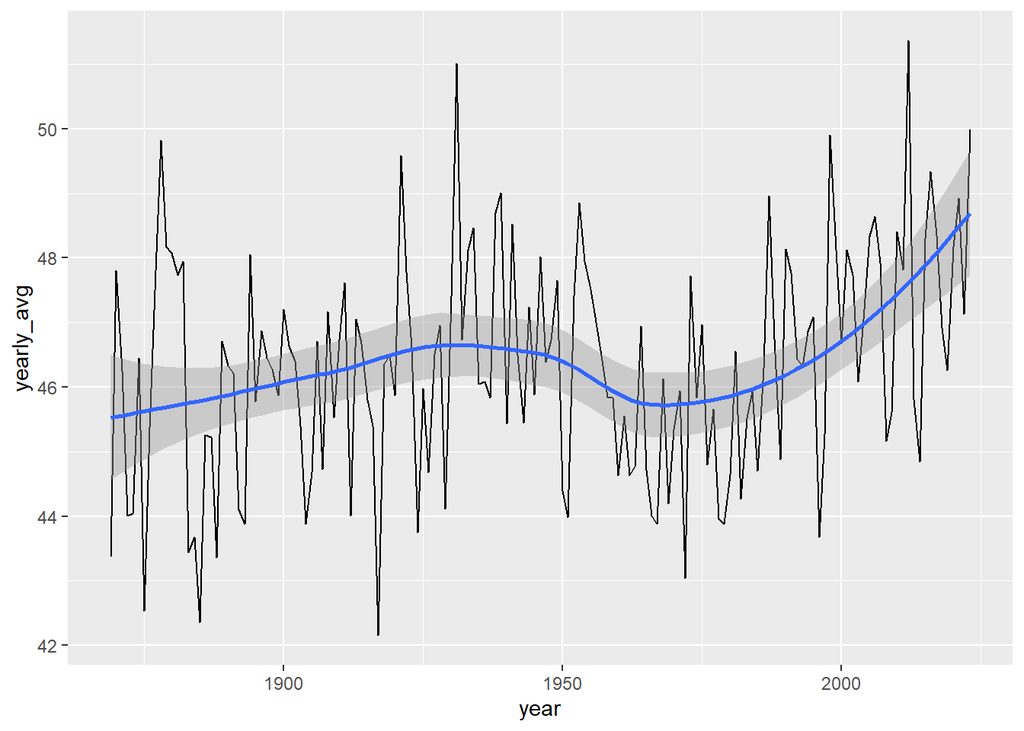

```r
official %>%
  drop_na(tavg) %>%
  group_by(year) %>%
  summarize(yearly_avg = mean(tavg)) %>%
  ggplot(aes(x = year, y = yearly_avg)) +
  geom_line() +
  geom_smooth()
```

**Daily Temperature Records**

(Hints: We will have to evaluate which row in `official` has the highest `tmax` within each combination of `month` and `day`. We can do that with `group_by` leading into `slice_max`. )

```r
official %>%
  group_by(month, day) %>%
  slice_max(tmax, n = 1)
```

```
## # A tibble: 454 × 11
## # Groups:   month, day [366]
##    name    date        prcp  snow snow_depth  tmin  tmax  tavg  year month   day
##    <chr>   <date>     <dbl> <dbl>      <dbl> <dbl> <dbl> <dbl> <dbl> <ord> <int>
##  1 Bureau  1897-01-01  0.32     0         NA    42    54  48    1897 Jan       1
##  2 Bureau  1897-01-02  0.32     0         NA    32    53  42.5  1897 Jan       2
##  3 Bureau  1874-01-03  0       NA         NA    39    57  48    1874 Jan       3
##  4 Bureau  1880-01-04  0.5     NA         NA    36    53  44.5  1880 Jan       4
##  5 Airport 2012-01-05  0        0          0    21    51  36    2012 Jan       5
##  6 Bureau  1880-01-06  0.06    NA         NA    39    58  48.5  1880 Jan       6
##  7 Airport 2008-01-07  0.59     0          3    34    50  42    2008 Jan       7
##  8 Airport 2003-01-08  0        0          0    30    54  42    2003 Jan       8
##  9 Bureau  1939-01-09  0.18     0          0    37    53  45    1939 Jan       9
## 10 Airport 2002-01-09  0        0          0    38    53  45.5  2002 Jan       9
## # ℹ 444 more rows
```

**30-year Period**

Meteorologists often determine weather norms by averaging over a 30-year period. Create a new variable which indicates what 30-year period a given day is part of; starting with 1871-1900, then 1901-1930, up to 1991-2020. You can exclude years before 1871 and after 2020.

```r
official <- official %>%
  mutate(period = case_when(
    year > 1870 & year <= 1900 ~ "1871-1900",
    year > 1900 & year <= 1930 ~ "1901-1930",
    year > 1930 & year <= 1960 ~ "1931-1960",
    year > 1960 & year <= 1990 ~ "1961-1990",
    year > 1990 & year <= 2020 ~ "1991-2020",
  ))
```

**Temperature by Period**

Then, with that 30-year-period variable you just created, calculate within each of the twelve months within each period (e.g. 1 row for all Januarys in 1871-1900, 1 row for all Februarys in 1871-1900… for each month, for each period) the average, maximum, and minimum of `tavg`.

(Take a moment to make sure you understand what the question is asking for. We have 5 periods and there are twelve unique months in each period (e.g. January 1871 is lumped together with every other January from 1871 - 1900) so we will get 60 rows. We’ll also need to only keep those rows between 1871 and 2020.)

**Days with Precipitation**

Make a summary table which shows the proportion of days which had any precipitation in each 30-year period + month combination.

Create a column graph of the percentage of days with precipitation in each 30-year period. Add the `facet_wrap` code to your graph to make a separate panel based on month.

```r
# Add this layer to your graph with '+' when you're ready
#facet_wrap(vars(month))
```